# ClassNotes9.29

Author

Adam Kaderbhai

```r
library(tidyverse)
```

## Missing data

Broadly speaking, there are three kinds of missing data.

1. **Missing completely at random**, where a random sample of observations are deleted or missing. This is how `slice_sample` works. When doing plots or models, R and other languages assume this type.
2. **Missing at random**, where there are correlations with other variables, but still randonimity in the missingness. It’s sometimes possible to *impute* the missing values in this situation.
3. **Missing not at random**, where there are real-world reasons for missing data that may not be apparent from the spreadsheet.

## Example: the `msleep` set.

```r
glimpse(msleep)
```

```
Rows: 83
Columns: 11
$ name         <chr> "Cheetah", "Owl monkey", "Mountain beaver", "Greater shor…
$ genus        <chr> "Acinonyx", "Aotus", "Aplodontia", "Blarina", "Bos", "Bra…
$ vore         <chr> "carni", "omni", "herbi", "omni", "herbi", "herbi", "carn…
$ order        <chr> "Carnivora", "Primates", "Rodentia", "Soricomorpha", "Art…
$ conservation <chr> "lc", NA, "nt", "lc", "domesticated", NA, "vu", NA, "dome…
$ sleep_total  <dbl> 12.1, 17.0, 14.4, 14.9, 4.0, 14.4, 8.7, 7.0, 10.1, 3.0, 5…
$ sleep_rem    <dbl> NA, 1.8, 2.4, 2.3, 0.7, 2.2, 1.4, NA, 2.9, NA, 0.6, 0.8, …
$ sleep_cycle  <dbl> NA, NA, NA, 0.1333333, 0.6666667, 0.7666667, 0.3833333, N…
$ awake        <dbl> 11.9, 7.0, 9.6, 9.1, 20.0, 9.6, 15.3, 17.0, 13.9, 21.0, 1…
$ brainwt      <dbl> NA, 0.01550, NA, 0.00029, 0.42300, NA, NA, NA, 0.07000, 0…
$ bodywt       <dbl> 50.000, 0.480, 1.350, 0.019, 600.000, 3.850, 20.490, 0.04…
```

Let’s start by looking at conservation status. We can learn about the abbreviations used on the internet. What about the `NA`s for this variable? Let’s start by isolating these observations.

```r
conserv_na <- msleep %>%
  filter(is.na(conservation))

gt::gt(conserv_na)
```

| name | genus | vore | order | conservation | sleep_total | sleep_rem | sleep_cycle | awake | brainwt | bodywt |
| --- | --- | --- | --- | --- | --- | --- | --- | --- | --- | --- |
| Owl monkey | Aotus | omni | Primates | NA | 17.0 | 1.8 | NA | 7.0 | 0.01550 | 0.480 |
| Three-toed sloth | Bradypus | herbi | Pilosa | NA | 14.4 | 2.2 | 0.7666667 | 9.6 | NA | 3.850 |
| Vesper mouse | Calomys | NA | Rodentia | NA | 7.0 | NA | NA | 17.0 | NA | 0.045 |
| African giant pouched rat | Cricetomys | omni | Rodentia | NA | 8.3 | 2.0 | NA | 15.7 | 0.00660 | 1.000 |
| Western american chipmunk | Eutamias | herbi | Rodentia | NA | 14.9 | NA | NA | 9.1 | NA | 0.071 |
| Galago | Galago | omni | Primates | NA | 9.8 | 1.1 | 0.5500000 | 14.2 | 0.00500 | 0.200 |
| Human | Homo | omni | Primates | NA | 8.0 | 1.9 | 1.5000000 | 16.0 | 1.32000 | 62.000 |
| Macaque | Macaca | omni | Primates | NA | 10.1 | 1.2 | 0.7500000 | 13.9 | 0.17900 | 6.800 |
| Vole | Microtus | herbi | Rodentia | NA | 12.8 | NA | NA | 11.2 | NA | 0.035 |
| Little brown bat | Myotis | insecti | Chiroptera | NA | 19.9 | 2.0 | 0.2000000 | 4.1 | 0.00025 | 0.010 |
| Slow loris | Nyctibeus | carni | Primates | NA | 11.0 | NA | NA | 13.0 | 0.01250 | 1.400 |
| Chimpanzee | Pan | omni | Primates | NA | 9.7 | 1.4 | 1.4166667 | 14.3 | 0.44000 | 52.200 |
| Baboon | Papio | omni | Primates | NA | 9.4 | 1.0 | 0.6666667 | 14.6 | 0.18000 | 25.235 |
| Deer mouse | Peromyscus | NA | Rodentia | NA | 11.5 | NA | NA | 12.5 | NA | 0.021 |
| Phalanger | Phalanger | NA | Diprotodontia | NA | 13.7 | 1.8 | NA | 10.3 | 0.01140 | 1.620 |
| Potoroo | Potorous | herbi | Diprotodontia | NA | 11.1 | 1.5 | NA | 12.9 | NA | 1.100 |
| African striped mouse | Rhabdomys | omni | Rodentia | NA | 8.7 | NA | NA | 15.3 | NA | 0.044 |
| Squirrel monkey | Saimiri | omni | Primates | NA | 9.6 | 1.4 | NA | 14.4 | 0.02000 | 0.743 |
| Cotton rat | Sigmodon | herbi | Rodentia | NA | 11.3 | 1.1 | 0.1500000 | 12.7 | 0.00118 | 0.148 |
| Mole rat | Spalax | NA | Rodentia | NA | 10.6 | 2.4 | NA | 13.4 | 0.00300 | 0.122 |
| Musk shrew | Suncus | NA | Soricomorpha | NA | 12.8 | 2.0 | 0.1833333 | 11.2 | 0.00033 | 0.048 |
| Short-nosed echidna | Tachyglossus | insecti | Monotremata | NA | 8.6 | NA | NA | 15.4 | 0.02500 | 4.500 |
| Eastern american chipmunk | Tamias | herbi | Rodentia | NA | 15.8 | NA | NA | 8.2 | NA | 0.112 |
| Tenrec | Tenrec | omni | Afrosoricida | NA | 15.6 | 2.3 | NA | 8.4 | 0.00260 | 0.900 |
| Tree shrew | Tupaia | omni | Scandentia | NA | 8.9 | 2.6 | 0.2333333 | 15.1 | 0.00250 | 0.104 |
| Bottle-nosed dolphin | Tursiops | carni | Cetacea | NA | 5.2 | NA | NA | 18.8 | NA | 173.330 |
| Genet | Genetta | carni | Carnivora | NA | 6.3 | 1.3 | NA | 17.7 | 0.01750 | 2.000 |
| Arctic fox | Vulpes | carni | Carnivora | NA | 12.5 | NA | NA | 11.5 | 0.04450 | 3.380 |
| Red fox | Vulpes | carni | Carnivora | NA | 9.8 | 2.4 | 0.3500000 | 14.2 | 0.05040 | 4.230 |

Some googling tells us that these species weren’t endangered at the time the set was made. These `NA`s aren’t random. They mean something. We could replace these `NA`s with “not endangered” or something. A useful command is `tidyr::replace_na`.

What about `sleep_rem`? Is the missingness of this variable related to other variables in the set? We might try to answer this by making some plots where missingness is a variable. Let’s just check vs `vore`. Ideally, you should check vs every variable of interest in your analysis.

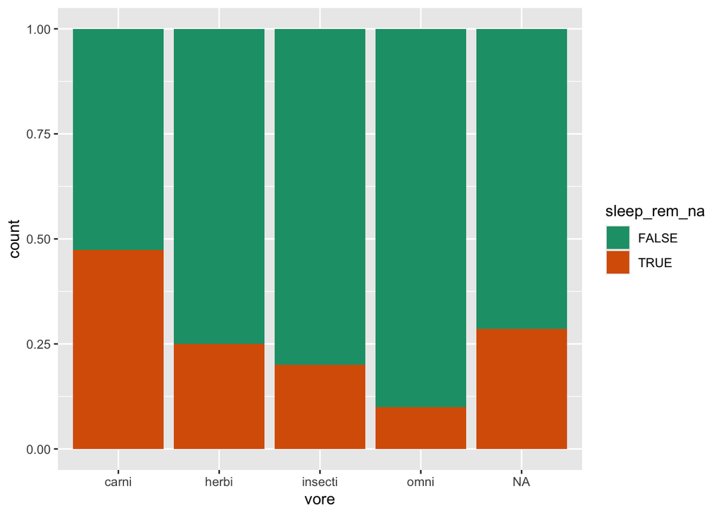

```r
msleep <- msleep %>%
  mutate(sleep_rem_na = is.na(sleep_rem))

ggplot(msleep, aes(x = vore,
                   fill = sleep_rem_na)) +
  geom_bar(position = "fill") +
  scale_fill_brewer(palette = "Dark2")
```

If we drop observations with missing `sleep_rem`, we’ll disproportionately be dropping carnivores, which probably isn’t great.